# Model Selection

# Load libraries

```r
library(formattable)
library(caret)
library(Metrics)
library(dplyr)
library(randomForest)
library(gbm)
```

Now that I know which independent variables to include in my final model, I have to select the best model for my predictions.

# Create data frame of final independent and dependent variables

```r
manhattan_ints <- read.csv("https://raw.githubusercontent.com/lcao21/GIS3_Final_Project/master/Data/manhattan_ints.csv", stringsAsFactors = FALSE)

# Keep only necessary columns
manhattan_final <- manhattan_ints[c(16,8,11,12,20,22,23,24)]

# Convert LAND.SQUARE.FEET and GROSS.SQUARE.FEET to numeric
manhattan_final$LAND.SQUARE.FEET <- gsub(",","",manhattan_final$LAND.SQUARE.FEET)
manhattan_final$GROSS.SQUARE.FEET <- gsub(",","",manhattan_final$GROSS.SQUARE.FEET)
manhattan_final[,c(3:4)] <- data.frame(apply(manhattan_final[c(3:4)], 2, as.numeric))

formattable(head(manhattan_final))
```

| SALE.PRICE | RESIDENTIAL.UNITS | LAND.SQUARE.FEET | GROSS.SQUARE.FEET | num_schools | num_parks | num_subway | neighborhood_ord |
| --- | --- | --- | --- | --- | --- | --- | --- |
| 13000000 | 1 | 1434 | 5339 | 0 | 18 | 0 | 13 |
| 7200000 | 1 | 1839 | 4344 | 0 | 14 | 1 | 15 |
| 11200000 | 1 | 1665 | 4060 | 2 | 20 | 6 | 12 |
| 1550000 | 1 | 1081 | 2800 | 0 | 13 | 0 | 5 |
| 19900000 | 1 | 2581 | 8125 | 3 | 5 | 5 | 12 |
| 6800000 | 3 | 1575 | 2646 | 0 | 41 | 3 | 12 |

```r
str(manhattan_final)
```

```
## 'data.frame':    183 obs. of  8 variables:
##  $ SALE.PRICE       : num  13000000 7200000 11200000 1550000 19900000 ...
##  $ RESIDENTIAL.UNITS: int  1 1 1 1 1 3 2 2 1 2 ...
##  $ LAND.SQUARE.FEET : num  1434 1839 1665 1081 2581 ...
##  $ GROSS.SQUARE.FEET: num  5339 4344 4060 2800 8125 ...
##  $ num_schools      : int  0 0 2 0 3 0 0 1 0 5 ...
##  $ num_parks        : int  18 14 20 13 5 41 12 27 20 43 ...
##  $ num_subway       : int  0 1 6 0 5 3 1 2 2 4 ...
##  $ neighborhood_ord : int  13 15 12 5 12 12 15 8 15 14 ...
```

Outliers can skew model predictions results, so I remove any rows with extremely low sale prices. There are multiple rows with sale price values less than 100, which doesn’t make sense because the units are in dollars and most sale prices are at least $100,000.

# Remove outliers

```r
manhattan_final <- manhattan_final[!(manhattan_final$SALE.PRICE < 100),]
summary(manhattan_final$SALE.PRICE)
```

```
##     Min.  1st Qu.   Median     Mean  3rd Qu.     Max.
##   319393  2708000  6367000  8136732 11162500 77100000
```

# Check for any missing data

```r
which(is.na(manhattan_final))
```

```
## integer(0)
```

There’s no missing data so I can go on to partition the dataset into two sets: a training set (70% of the dataset) and a testing set (30%).

# Partition data

```r
set.seed(400)
in_training <- createDataPartition(manhattan_final$SALE.PRICE, p = 0.70, list=FALSE)
training <- droplevels(manhattan_final[in_training,])
testing <- droplevels(manhattan_final[-in_training,])
```

Now, I can start training my different models. For each model, I also calculate the mean absolute error (MAE) so that I can pick the model with the smallest MAE. I will be fitting the following models on the data:

**Regression Models**:

1. OLS
2. Poisson

**Tree-Based Models**:

3. Random Forest
4. GBM

# Regression Models

## OLS

```r
fit_ols <- lm(SALE.PRICE ~ ., data = training)

y_hat_ols <- predict(fit_ols, testing)
ols_mae <- mae(testing$SALE.PRICE, y_hat_ols)
```

## Poisson

```r
fit_poisson <- glm(SALE.PRICE ~ ., data = training, family="poisson")

y_hat_poisson <- predict(fit_poisson, testing, type = "response")
pois_mae <- mae(testing$SALE.PRICE, y_hat_poisson)
```

# Tree-Based Models

## Random Forest

```r
fit_rf <- randomForest(SALE.PRICE ~ ., data = training)

y_hat_rf <- predict(fit_rf, testing)
rf_mae <- mae(testing$SALE.PRICE, y_hat_rf)
```

While random forests build an ensemble of deep independent trees, GBM (generalized boosted machine) models build one of shallow and weak successive trees, each tree learning and improving on the previous. The below gbm model generates 10000 trees, has a shrinkage parameter (learning rate) of 0.01, and has an interaction depth–the total splits–to 4, so each tree is a small tree with only 4 splits. Furthermore, I chose a gaussian distribution to minimize squared error.

## GBM

```r
fit_gbm <- gbm(SALE.PRICE ~ ., data = training ,distribution = "gaussian", n.trees = 10000, shrinkage = 0.01, interaction.depth = 4)

y_hat_gbm <- predict(fit_gbm, testing, n.trees = 10000)
gbm_mae <- mae(testing$SALE.PRICE, y_hat_gbm)
```

Here are the final results from all the models:

```r
results <- data.frame()
ols <- c("OLS", ols_mae)
pois <- c("Poisson", pois_mae)
rf <- c("Random Forest", rf_mae)
gbm <- c("Gradient Boosting", gbm_mae)

results <- rbind(ols, pois, rf, gbm)
rownames(results) <- c()
colnames(results) <- c("Model", "Mean Absolute Error (MAE)")

formattable(as.data.frame(results))
```

| Model | Mean Absolute Error (MAE) |
| --- | --- |
| OLS | 3245930.12240883 |
| Poisson | 2825461.74847383 |
| Random Forest | 2695621.42204946 |
| Gradient Boosting | 3485649.59140536 |

The mean absolute errors from all four models are all in the millions (huge!), which I think is best explained by the small size of the dataset (only 175 rows) and that the average sale price in the dataset is 8,136,732. Nevertheless, I will pick the Random Forest model because it still has the smales MAE.

```r
dim(manhattan_final)
```

```
## [1] 175   8
```

```r
mean(manhattan_final$SALE.PRICE)
```

```
## [1] 8136732
```

From the predicted vs. actual plot for the testing set, we can see that quite a few predictions using the Random Forest model are decently if not very close, but there are also a number that are far off.

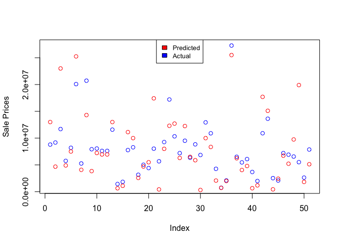

```r
plot(y_hat_rf, ylab = "Sale Prices", col = "Blue")
points(testing$SALE.PRICE, col="Red")
legend("top", legend=c("Predicted", "Actual"),
       fill=c("Red", "Blue"), cex=0.8)
```